##### Author: Muhammed Abojabal, Email: moh.aboajabl@gmail.com

# Project 1, Udacity Data Analyst Nano-degree: Exploring Weather Trends.

#### In this project, I will analyze local and global temperature data and compare the temperature trends where I live to overall global temperature trends.

### Extracting the data

1- city_data (Alexandria) - This contains the average temperatures for each city by year (ºC).  
a SQL query to extract the city level data. Exported to CSV with name 'city_data.csv'.

```
                                                                        SELECT *
                                                                        FROM city_data
                                                                        WHERE country = 'Egypt' AND city = 'Alexandria';
```

[figure not shown]

2- global_data - This contains the average global temperatures by year (ºC).

```
                                                                                                SELECT *
                                                                                                FROM global_data;
```

[figure not shown]

### IMPORTING PYTHON DATA SCIENCE PACKAGES, USED IN THE ANALYSIS OF DATA.

```python
import pandas as pd

import matplotlib.pyplot as plt
import numpy as np

plt.rcParams["figure.figsize"] = [10, 8]
```

## OPENING UP THE CSV FILES

```python
city_data     = pd.read_csv('city_data.csv')

global_data = pd.read_csv('global_data.csv')
```

```python
city_data.head()
```

|  | year | city | country | avg_temp |
| --- | --- | --- | --- | --- |
| 0 | 1791 | Alexandria | Egypt | 22.60 |
| 1 | 1792 | Alexandria | Egypt | 20.17 |
| 2 | 1793 | Alexandria | Egypt | 19.94 |
| 3 | 1794 | Alexandria | Egypt | 20.31 |
| 4 | 1795 | Alexandria | Egypt | 20.22 |

```python
global_data.head()
```

|  | year | avg_temp |
| --- | --- | --- |
| 0 | 1750 | 8.72 |
| 1 | 1751 | 7.98 |
| 2 | 1752 | 5.78 |
| 3 | 1753 | 8.39 |
| 4 | 1754 | 8.47 |

### Moving Average for the Global data and City data.

Now that I could extract data from a database, let's talk through the next step of completing the project: moving averages.  
Moving averages are used to smooth out data to make it easier to observe long term trends and not get lost in daily fluctuations  
Using a moving average, you can both smooth out the daily volatility and allow you to observe the long term trend.

### Moving Average with Python:

Simple, cumulative, and exponential moving averages with Pandas  
The moving average is also known as rolling mean.

The easiest way to calculate the simple moving average is by using the `pandas.Series.rolling` method.

```python
global_avg = global_data['avg_temp'].rolling(20, min_periods=2).mean()

city_avg = city_data['avg_temp'].rolling(20, min_periods=2).mean()
```

### CREATING THE LINE CHARTS

#### Visualisations is done by matplotlib.pyplot python library.

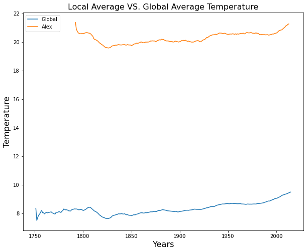

```python
plt.plot(global_data['year'], global_avg, label='Global')
plt.plot(city_data['year'], city_avg, label='Alex')

plt.legend()
plt.xlabel("Years", fontsize=16)
plt.ylabel("Temperature", fontsize=16)
plt.title("Local Average VS. Global Average Temperature", fontsize=16)
plt.show()
```

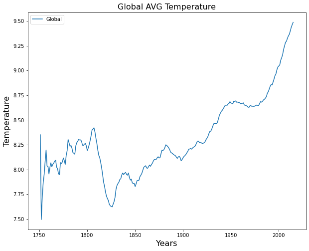

```python
plt.plot(global_data['year'], global_avg, label='Global')

plt.legend()
plt.xlabel("Years",  fontsize=16)
plt.ylabel("Temperature",  fontsize=16)
plt.title("Global AVG Temperature",  fontsize=16)
plt.show();
```

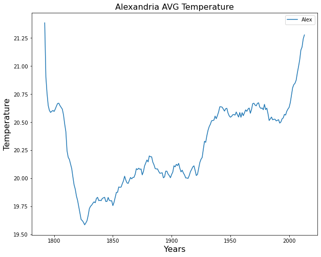

```python
plt.plot(city_data['year'], city_avg, label='Alex')

plt.legend()
plt.xlabel("Years",  fontsize=16)
plt.ylabel("Temperature",  fontsize=16)
plt.title("Alexandria AVG Temperature", fontsize=16)
plt.show();
```

## MAKING OBSERVATIONS:

1- The local temperature in Alexandria, in 1800 Was greatly high as before 1950. What Was the Problem then? There were no oil mining yet And Higher than the global average.

2- After 1800, temperature in alexandria decresed greatly.

3- After 1930, the temperature began to increase fastly with time.

4- The Local Temprature in Alexandria was higher than the global temprature before 1800.

5- The Global temperature started to raise since the middle of 1800.

6- The Highest inflation was before 2000 over the global average.